# Assignment 1

Yuhaniz Aly

4/23/2021

## Describing Metrics

There are many different measurement of disease burden, which includes deaths, YLLs, YLDs, DALYS.

**Years of Life Lost (YLLs)** measures the years of potential life lost due to premature deaths. To calculate YLLs for a particular outcome in a population, we use the life expectancy for the given age minus the age, multiplied by the number of deaths.

**Years Lived with Disability (YLDs)** measures the years of potential life lost due to living with a disability. To calculate YLDs for a particular outcome in a population, we use the disability weight, which is the magnitude of the impairment, multiplied by the number of people living with that impairment in that population (prevalence).

**Disability Adjusted Life Years (DALYs)** is a measure of overall disease burden, expressed the years of potential life lost due to ill-health, disability, or premature death. DALYs combines mortality and morbidity into one metric. To calculate DALYs for a particular outcome in a population, we take the sum of the years life lost due to premature deaths (YLLs) and the years life lost due to living with a disability (YLDs).

**Disability weights** quantifies the severity of outcomes as percentage reduction from perfect health, which are multiplied by prevalent cases. Disability weights is measured from a scale of 0 to 1, with 0 implying the state in full health and 1 implying a state of death.

**Age-weighting** provides different values to life years lived at different ages. Age-weighting assumes that a year of life increases in value until age 22, and then decreases. I think age-weighting should be included in the calculations of DALYs because I think young adulthood are when people are in their prime years of health and less susceptible to contracting a disease that would put them close to a near-death situation.

**Discounting** is an adjustment that reduces the burden of early mortality. Discounting counts the years of healthy life saved in the present more valuable than years of life saved in the future. I think discounting should not be included in the calculations of DALYs because of the uncertainty correlating with time. Some individuals might want to estimate their personal risk of death each year at their own rate and preference, as it may vary from year to year, rather than go with the default discount rate.

## Burden by Cause

This section compares the different measurements of health burden (deaths, YLLs, YLDs, DALYs) across causes.

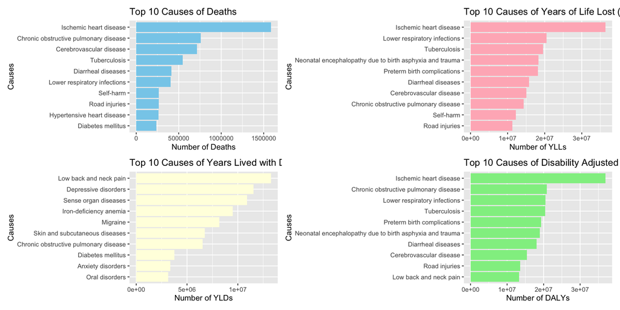

The barcharts shows the top 10 causes of the various metrics of health. Based on the barcharts, *ischemic heart disease* is the number one top cause of health burden, as it has the most number of deaths, YLLs, and DALYs. The barchart illustrates that ischemic heart disease has significantly more cases of deaths, YLLs, and DALYs than any other causes. In contrast, *low back and neck pain* has the most number of YLDs. In fact, ischemic heart disease did not appear to be one of the top 10 causes for YLDs. This suggests that many people diagnosed with ischemic heart disease tend to die from this disease and that many people lose many years of their lifetime, which explains the large number of deaths, YLLs, and DALYs. This means there will be fewer people living with ischemic heart disease because they do not survive as long. This means there will be less cases of people living with ischemic heart disease, which is why ischemic heart disease is not a top 10 cause for YLDs. Meanwhile, low back and neck pain cases are less severe on people’s health and more common in the population, resulting YLDs to be more prevalent.

## Burden by Age

This section compares the different measurements of health burden (deaths, YLLs, YLDs, DALYs) across ages between 0 to 80 years old. Note: Children under 5 were indicated as age 0 in the graphs.

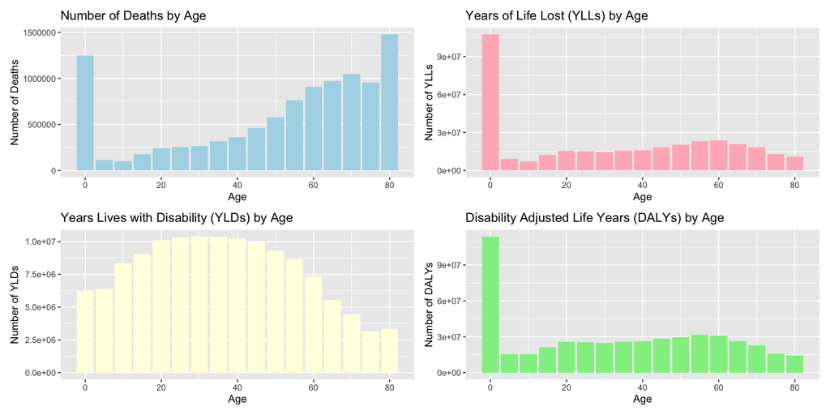

The light blue barchart shows that the *number of deaths increases across increasing age*, with people over 80 having the most deaths. On the other hand, children under 5 have the second most deaths. This is not surprising because we can expect an average person’s life expectancy to be around the 80s, though it may slightly vary depending on geographic location. Also, children dying before the age of 5 is unfortunately common across the world. This accounts for the *large number of YLLs and DALYs in the under 5 age group* because many children lost so many years of their potential lifetime from an early death. The graphs (light pink and light green barcharts) also show that in the later life, YLLs and YLDs leveled off in older age groups. This means they do not have a high life expectancy, resulting in a lower YLLs and DALYs value. On the other hand, the light yellow barchart shows that *the middle age groups, between 30 to 40 years old, tend to have the most YLDs* .This is also not surprising because people in this age group tend to be affected by health condition at this in their lifetime. The older groups (65 years and older) have less YLDs because there not many people who reach this age in life, which we can see in the light blue barchart.

## Burden by Sex

This section compares the different measurements of health burden (deaths, YLLs, YLDs, DALYs) across sexes, males and females.

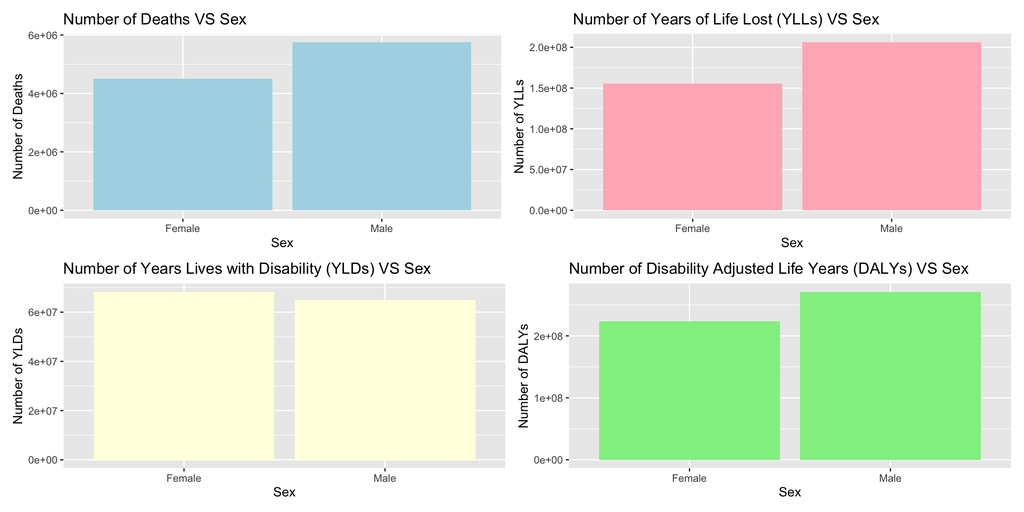

Across three of the barcharts (light blue, light pink, and light green), they illustrate that *males have more number of deaths, YLLs, and DALYs than females*. Whereas in the light yellow barchart, *females have more YLDs than males*. This suggest that males die more than females and that they lose more years their lifetime from the health cause/disease. This also means that more females live the disease or disabilty than males and that females do not lose many years of their lifetime from the cause than males. Additionally, this may suggest that there are more males in the population affected by diseases than females because males die the most.